# G Luku 1 Yksinkertainen korrespondenssianalyysi

Jussi Hirvonen

25.4.2018

Kommentteja ja versionhallintaa:

- edit: oma kommentti, ei varsinaista tekstiä
- kirjastot/paketit ladataan jokaisessa Rmd-dokumentissa
- bib-formaatin viitetietokantaa tullaan kokeilemaan
- kuvasuhde (aspect ratio) edelleen epäselvä juttu!
- Datan käsittely ja hallinta +SPSS:n sallima kolme puuttuvan tiedon koodia saadaan mukaan read_spss-funktion (haven) parametrilla USER_NA = TRUE (mutta tarkistettava!) (25.5.18)
- faktoreita ei ainakaan toistaiseksi muuteta ordinaaliasteikolle, CA ei tästä välitä
- pidetään muuttujien ja tiedosojen nimeäminen selkeänä, tarkistetaan aika ajoin
- Taulukot: lisättiin riviprosentti- ja sarakeprosenttitaulut (25.5.18)

# 1 Data

Ladataan käytettävät paketit:

```r
# pitääkö laittaa järjestykseen, vanhemmat ensin?
library(rgl)
library(ca)
library(haven)
library(dplyr)
library(knitr)
library(tidyverse)
library(lubridate)
```

```r
library(rmarkdown)
library(ggplot2)
library(furniture)
library(likert)
library(scales)   # ggplot2 - kuvalle
library(reshape2) # ggplot2 - kuvalle
```

Yksinkertainen korrespondenssianalyysi on kahden luokitteluasteikon muuttujan riippuvuuksien geometrista analyysiä. Lähtökohta on kahden muuttujan ristiintaulukointi, alkuperäinen data voi olla muillakin asteikoilla mitattua. Menetelmän ydin on tarkastella molempien muuttujien – taulukon rivien ja sarakkeiden – riippuvuuksia kaksiulotteisena kuvana. Kuvaa kutsutaan myös kartaksi, ja tulkinnan ensimmäinen askel on kartan “koordinaatiston” tulkinta. Kaikki etäisyydet kuvassa ovat suhteellisia, vain rivi- ja sarakepisteiden etäisyydet kuvan origosta voidaan tulkita tarkasti. Koordinaatiston tulkinta aloitetaan “katsomalla mitä on oikealla ja vasemmalla, ja mitä on ylhäällä ja alhaalla” (viite LeRoux et.al, Bezecri-sitaatti). Vaikka pisteiden etäisyyksiä edes rivi- ja sarakepisteiden välillä ei voi tarkkaan tulkita (approksimaatioita), projektiossa kaukana toisistaan olevat pisteet ovat kaukana toisistaan myös alkuperäisessä “pistepilvessä”.

## 1.1 Luvun 1 tavoitteet

1. Data - tässä tiiviimmin, aineiston kuvailu tarkemmin liitteeseen. Perustella rajaukset ja kertoa miten ne tehdään.
2. Ensimmäinen taulukko: profiilit, massat, keskiarvoprofiilit, khii2 - riippumattomuustesti ja etäisyysmitta
3. Hyvin tiivis esitys CA:n perusideasta, mutta ilman aivan simppeleitä kolmiulotteisia kuvia (niitä on jo)
4. Ensimmäinen symmetrinen kartta, perustulkinta (mitä kuvasta voidaan sanoa, mitä ei)
5. Lyhyt viittaus graafisen esityksen tulkintapulmiin, jotka eivät ole kovin pahoja. Niihin palataan kaksoiskuva-jaksossa.
6. Tulkinnan syventäminen - “kaikki selitetätään”

## 1.2 Perhe ja muuttuvat sukupuoliroolit - ISSP:n kyselytutkimuksen data 2012

Hieman historiaa datasta, sosiaalisesti määräytyneen sukupuoliroolit (gender) tutkimusaiheena neljässä kansainvälisessä kyselytutkimuksessa.

ISSP Research Group (2016): International Social Survey Programme: Family and Changing Gender Roles IV - ISSP 2012. GESIS Data Archive, Cologne. ZA5900 Data file Version 4.0.0, doi:10.4232/1.12661

[Aineistot] (https://search.gesis.org/research_data/ZA5900) 2012

[Muuttujakuvaukset ja muut tiedot] (http://zacat.gesis.org/webview/index.jsp?object=http://zacat.gesis.org/obj/fStudy/ZA5900)

[Suomenkielinen lomake (ZA5900_q_fi-fi.pdf)] (https://dbk.gesis.org/dbksearch/sdesc2.asp?no=5900&db=e&doi=10.4232/1.12661)

[Käyttöehdot:] (https://www.gesis.org/en/services/data-analysis/more-data-to-analyze/data-archive-service/)

[Tiedonkeruumenetelmä ja otoskoko:] (https://dbk.gesis.org/dbksearch/sdesc2.asp?no=5900&db=e&doi=10.4232/1.12661) Viimeisin Portugali 29.06.2014 - 31.01.2015, ensimmäinen Bulgaria 16.08.2011 - 20.09.2011. Suurin osa muista 2012-13, kuten Suomi (21.09.2012 - 07.12.2012 ).

edit: aineiston kuvailua voi ja kannattaakin jatkossa tarkentaa, ja laittaa se liitteeksi. Dokumentointi on hyvin tarkka, tiedot löytyvät haastattelumenetelmista (parerilomake, tietokoneavusteinen haastattelu, jne), maakohtaisten taustamuuttujien harmonisoinnista maittain, otantamenetelmistä jne. Esittelen vain aineiston tärkeimmät rajaukset.

## 1.3 Aineiston rajaaminen

Ainestossa (jatkossa ISSP2012) on kyselytutkimukseen tulokset 41 maasta. Lisäksi aineistossa on runsaasti demografisia ja muita taustatietoja. R-koodista selviää käytetty versio (SPSS-tiedoston nimi) ja rajauksessa käytetyt muuttujat.

## 1.4 Rajaukset

1. Eurooppa ja samankaltaiset maat (28)

Bulgaria, Czech Republic, Denmark, Finnland,France, Germany, Great Britain, Ireland, Latvia, Lithuania, Norway, Poland, Sweden, Slovakia Slovenia, Spain, Switzerland, Australia, Austria, Canada, Croatia, Iceland, Russia, United States, Belgium, Hungary, Netherlands, Portugal

Pois jätettiin 13: Argentiina,Turkki, Venezuela, Etelä-Afrikka, Korea, Intia, Kiina, Taiwan, Filippiinit, Meksiko, Israel, Japani, Chile.

**edit:** Tähän täsmennetään miten puuttuvia tietoja käsitellään.

4. Datan hallinta

Aineistoa käsitellään ja muokataan niin, että jokaisen analyysin voi mahdollisman yksinkertaisesti toistaa suoraan alkuperäisestä datasta.

Aineiston muokkauksen (muuttujien ja havaintojen valikointi, muunnokset ja uusien muuttujien luonti jne.) dokumentoidaan r-koodiin.

```r
# kolme maa-muuttujaa datassa. V3 erottelee joidenkin maiden alueita, V4 on koko maan
#two country code variables based on the ISO Code 3166. One identifies
#countries as a whole, the other one possible subsamples, such as East and West Germany. The cross
#tabulations shown in this Variable Report are based on a third, alphanumerical country code variable,
#which also identifies subsamples."
#V3 - Country/ Sample ISO 3166 Code (see V4 for codes for whole nation states)
# V3 erot valituissa maissa
# 5601 BE-FLA-Belgium/ Flanders
# 5602 BE-WAL-Belgium/ Wallonia
# 5603 BE-BRU-Belgium/ Brussels
# 27601 DE-W-Germany-West
# 27602 DE-E-Germany-East
# 62001 PT-Portugal 2012: first fieldwork round (main sample)
# 62002 PT-Portugal 2012: second fieldwork round (complementary sample)
# Myös tämä on erikoinen, näyttää olevan vakio kun V4 = 826:
# 82601 GB-GBN-Great Britain
# Portugalissa ainestoa täydennettiin, koska siinä oli puutteita. Jako ei siis ole oleellinen,
# mutta muuut ovat. Tähdellä merkityt maat valitaan johdattelevaan esimerkkiin.
# Maat:
# 36 AU-Australia
# 40 AT-Austria
# 56 BE-Belgium*
# 100 BG-Bulgaria*
# 124 CA-Canada
# 191 HR-Croatia
# 203 CZ-Czech Republic
# 208 DK-Denmark*
# 246 FI-Finland*
# 250 FR-France
# 276 DE-Germany*
# 348 HU-Hungary*
# 352 IS-Iceland
# 372 IE-Ireland
# 428 LV-Latvia
# 440 LT-Lithuania
# 528 NL-Netherlands
# 578 NO-Norway
# 616 PL-Poland
# 620 PT-Portugal
# 643 RU-Russia
# 703 SK-Slovakia
# 705 SI-Slovenia
# 724 ES-Spain
# 752 SE-Sweden
# 756 CH-Switzerland
# 826 GB-Great Britain and/or United Kingdom
# 840 US-United States
#
# Belgian ja Saksan alueet:
#  V3
#  5601     BE-FLA-Belgium/ Flanders
#  5602     BE-WAL-Belgium/ Wallonia
#  5603     BE-BRU-Belgium/ Brussels
# 27601     DE-W-Germany-West
# 27602     DE-E-Germany-East

#valittavien maiden kolminumeroinen ISO 3166 - koodi vektoriin
incl_countries <- c(36, 40, 56,100, 124, 191, 203, 208, 246, 250, 276, 348, 352, 372, 428, 440,
                    528, 578, 616, 620, 643, 703, 705, 724, 752, 756, 826, 840)
ISSP2012.data <- read_spss("data/ZA5900_v4-0-0.sav", user_na = TRUE)
#
# lisäys 25.4.2018 user_na
# "If TRUE variables with user defined missing will be read into labelled_spss objects.
# If FALSE, the default, user-defined missings will be # converted to NA"
# https://www.rdocumentation.org/packages/haven/versions/1.1.0/topics/read_spss
#
#
#
#str(ISSP2012.data) #61754 obs. of  420 variables
ISSP2012jh1.data <- filter(ISSP2012.data, V4 %in% incl_countries)
#length((ISSP2012jh1.data))
#names(ISSP2012jh1.data)
#str(ISSP2012jh1.data) #37816 obs. of  420 variables
#
#EDIT: tiivistä, nämä ovat vain kokeiluja ja datan kaivelua (15.4.2018)
#
# V5 - V67 kysymyksiä, joillain mailla omat vastaukset joihinkin omina muuttujina, esim.  #  ES_V5 muutkin Espanjan kysymykset (kaikki?)
#$ V5      :Class 'labelled'  atomic [1:37816] 5 1 2 2 1 NA 2 4 2 2 ...
#  .. ..- attr(*, "label")= chr "Q1a Working mom: warm relationship with children as a not working mom"
#  .. ..- attr(*, "format.spss")= chr "F1.0"
#  .. ..- attr(*, "labels")= Named num [1:8] 0 1 2 3 4 5 8 9
#  .. .. ..- attr(*, "names")= chr [1:8] "NAP: ES" "Strongly agree" "Agree" "Neither agree nor disagree" ...
# $ ES_V5   :Class 'labelled'  atomic [1:37816] NA NA NA NA NA NA NA NA NA NA ...
#  .. ..- attr(*, "label")= chr "Q1a Working mom: warm relationship with children as a not working mom"
#  .. ..- attr(*, "format.spss")= chr "F1.0"
#  .. ..- attr(*, "display_width")= int 4
#  .. ..- attr(*, "labels")= Named num [1:7] 0 1 2 3 4 8 9
#  .. .. ..- attr(*, "names")= chr [1:7] "NAP: other countries" "Strongly agree" "Agree" "Disagree" ...
#HU_V18
#V18$label
#attr(ISSP2012jh1.data$V6,'labels')
#attr(ISSP2012jh1.data$ES_V6,'labels')
```

```r
attr(ISSP2012jh1.data$ES_V5,'labels')
```

```
## NAP: other countries       Strongly agree                Agree
##                    0                    1                    2
##             Disagree    Strongly disagree         Can't choose
##                    3                    4                    8
##            No answer
##                    9
```

```r
temp1 <- ISSP2012jh1.data %>% filter(V4 == 724) %>% select(ES_V6, C_ALPHAN)
#str(temp1)
temp1$ES_V6 <- factor(temp1$ES_V6 )
summary(temp1)
```

```
##  ES_V6      C_ALPHAN
##  1: 195   Length:2595
##  2:1117   Class :character
##  3: 898   Mode  :character
##  4: 278
##  8:  91
##  9:  16
```

```r
#typeof(ISSP2012jh1.data)
#class(ISSP2012jh1.data)
#storage.mode(ISSP2012jh1.data)
#attributes(ISSP2012jh1.data)
```

## 1.5 Puuttuvat tiedot (erävastauskato)

**EDIT** tämä muuttuu kun puuttuvissa on tarkentava tieto mukana. Tuskin käytetään, joten tekstiä voi reipppaasti supistaa. (25.4.18)

Muiden kuin Espanjan vastaukset kysymykseen V6 jakautuvat näin:

```r
temp2 <- ISSP2012jh1.data %>% filter(!(V4 == 724)) %>% select(V6, C_ALPHAN)

#str(temp1)
temp2$V5 <- factor(temp2$V6 )
temp2$maa <-  factor(temp2$C_ALPHAN)
summary(temp2)
```

```
##        V6          C_ALPHAN         V5            maa
##  Min.   :1.000   Length:35221       1:2881   FR     : 2409
##  1st Qu.:2.000   Class :character   2:9019   BE     : 2202
##  Median :3.000   Mode  :character   3:6829   CZ     : 1804
##  Mean   :3.181                      4:9576   DE     : 1766
##  3rd Qu.:4.000                      5:5675   AU     : 1612
##  Max.   :5.000                      8: 875   RU     : 1525
##  NA's   :1241                       9: 366   (Other):23903
```

```r
temp2 %>% tableX(V6,maa,type = "count")
```

```
##          maa
## V6        AT   AU   BE   BG   CA  CH   CZ   DE   DK   FI   FR   GB-GBN
##   1       218  82   193  118  51  89   174  165  70   47   256  37
##   2       447  405  454  395  215 431  392  376  238  188  551  247
##   3       171  285  440  205  181 222  403  199  152  149  424  208
##   4       205  568  554  190  317 365  415  538  232  423  469  331
##   5       98   215  381  13   194 112  355  441  696  303  624  105
##   Missing 43   57   180  82   14  18   65   47   15   61   85   22
##   Total   1182 1612 2202 1003 972 1237 1804 1766 1403 1171 2409 950
##          maa
## V6        HR   HU   IE   IS   LT   LV   NL   NO   PL   PT   RU   SE   SI
##   1       75   219  56   13   50   188  59   23   110  73   244  29   39
##   2       265  288  250  138  438  395  296  186  395  495  542  124  272
##   3       190  225  197  186  396  156  242  226  155  157  360  219  200
##   4       327  190  478  552  220  209  445  579  365  215  254  276  365
##   5       133  75   197  271  22   38   196  365  64   52   42   354  131
##   Missing 10   15   37   12   61   14   77   65   26   9    83   58   27
##   Total   1000 1012 1215 1172 1187 1000 1315 1444 1115 1001 1525 1060 1034
##          maa
## V6        SK   US   Total
##   1       117  86   2881
##   2       246  350  9019
##   3       229  652  6829
##   4       298  196  9576
##   5       198  0    5675
##   Missing 40   18   1241
##   Total   1128 1302 35221
```

Tarkastellaan aineston puuttuvia havaintoja hieman tarkemmin. Puuttuvat tiedot on koodattu aineistoon näin: 0: Not applicapble (NAP), Not available (NAV) 7: (97,997, 9997,…): Refused 8: (98, 998, 9998,…): Don’t know 9: (99, 999, 9999,…): No answer

NAP ja NAV määritellään

“GESIS adds ‘Not applicable’(NAP) codes for questions that have filters. NAP indicates that only a subsample and not all of respondents were asked. Also in the case of country spesific variables, all the other countries are coded NAP.

GESIS adds ‘Not available’ for variables, which in singe countries may not have been conducted for whatever reason."

**EDIT:** Puuttuneisuuden lyhyttä kuvailua, ja rajausten vaikutus havaintojen lukumäärään muutamaan taulukkoon. Voi siirtää liitteisiin (25.4.2018)

```r
#Tähän lisätään erävastauskadon kuvailua - 10.4.2018
#Nyt edetään esimerkkin, jossa mukana kuusi maata ja kysymys V6 - palataan kun aineistoa laajennettaan.
```

### 1.5.1 Poikkeavat kysymykset

Aineistossa on ns. substanssimuuttujia 63 (V5 - V67). Suurin osa on kerätty jollain haastattelumenetelmällä, ja yleisin vastausvaihtoehto on viiden arvon Likert-skaala (1 = täysin samaa mieltä, samaa mieltä, en samaa enkä eri mieltä, eri mieltä, täysin eri mieltä =5). Eri maiden lomakkeissa on vaihtelua puuttuviksi tiedoiksi koodattujen muiden vastausten välillä. Esimerkikisi Suomen lomakkeessa on kuudes vaihtoehto “en osaa sanoa”, ja lisäksi on koodattu vastaamisesta kieltäytyminen tai muuten puuttuva tieto. SPSS-aineistossa nämä kaikki on koodattu puuttuviksi havainnoiksi.

Espanjan lisäksi Unkarin osatutkimuksessa kysymyksen V18 V19 V20 vastausvaihtoehdot ovat poikkeavat siten, että keskimmäinen neutraali vaihtoehto on jätetty pois (em.dok, s. 48).

**edit:** nämä merkinnät ovat muistiinpanoja, kun tarkemmin luin muuttujadokumenttia. Kysymyksissä on vaihtelua, ja tavallaan niin pitääkin olla kansainvälisessä kyselytutkimuksessa. Vastaajien on ymmärrettävä kysymyksen suurinpiirtein samalla tavalla. Kaikki on tarkasti dokumentoitu.

Islannissa kysymykseen V28 (Consider a couple who both work full-time and now have a new born child. One of them stops working for some time to care for their child. Do you think there should be paid leave available and, if so, for how long?) on tarjolla oma vastausvaihtoehto ((97) “Yes, but don’t know how many months”). Kysymyseen “V29 - Q9 Paid leave: Who should pay ja V30(Paid leave: How to divide between parents) Bulgarian kysely on poikkeava (0 NAP (code 0,98 in V28), s. 91).

Hollannin vastausvaihtoehdoissa kysymykseen V35 (Elderly people: Provider of domestic help) on oma variantti “5 Empoyers”, jonka kuitenkin on valinnut vain 6 vastajaa (0,5 %).

V39, V40, V41, V42, V43, V44, V45, V46, V47, V48, V50, V51, V52, V53, V54: paljon poikkeamia, aika vaikeaselkoisia kysymyksiä. Näitä ehkä pitää tutkailla… V55 (Life in general: How happy on the whole) ok.

V56-57 poikkeamia, V58 (Health status) ok V59 “ketjutettu kysymys”, samoin V60-V64. s. 174 - puolison koulutus…

**edit:** täsmennettävä, periaatteessa vastaukset on harmonisoitu. Joistain maista joku tieto puuttuu, jos sitä ei ole kysytty. Joissain tapauksissa kysymysten vaihtoehdot poikkeavat standardista.

# 2 Yksinkertainen korrespondenssianalyysi - kahden luokittelumuuttujan taulukko

Tässä esitellään yksinkertainen esimerkki, yksi kysymys (esim. V6) ja muutamia maita ristiintaulukoituna. Johdatteluna aiheeseen esitellään ca-käsitteet profiili, massa ja reunajakauma. Havainnollistetaan rivi- ja sarakeprofiilien vertailua vastaaviin keskiarvoprofiileihin.

Toiseksi riippumattomuushypoteesi ja $\chi^2$ - riippumattomuustesti (pieni huomautus - on monta tapaa testata taulukon riippuvuuksia). Riippumattomuushypoteesi ehdollisena todennäköisyytenä reunajakauman suhteen.

$\chi^2$ - etäisyys, yhteys hajontaa eli inertiaan ca-terminologiassa.

Dimensioiden vähentämisen idea.

Ensimmäinen symmetrinen kartta, tulkinnat ja yksinkertaisimmat perussäännöt (“mitä on oikealla ja vasemmalla”). Jos pisteet ovat alkuperäisessä “pilvessä” kaukana toisistaan, ne ovat sitä myös projektiossa. Kartta, mutta etäisyyksillä ei suoraa tulkintaa paitsi eteisyyksinllä origoon. Rivipisteiden suhteelliset etäisyydet, samoin sarakepisteiden, mutta ei muut.

## 2.1 Äiti työssä

Aineisto muuttujat V5-V9 ovat vastauksia (1-5 Likert, täysin samaa mieltä - täysin eri mieltä) seuraaviin kysymyksiin (suomenkielinen lomake, kysymys 23):

1. Työssäkäyvä äiti pystyy luomaan lapsiinsa aivan yhtä lämpimän ja turvallisen suhteen kuin äiti, joka ei käy työssä
2. Alle kouluikäinen lapsi todennäköisesti kärsii, jos hänen äitinsä käy työssä
3. Kaiken kaikkiaan perhe-elämä kärsii, kun naisella on kokopäivätyö
4. On hyvä käydä töissä mutta tosiasiassa useimmat naiset haluavat ensisijaisesti kodin ja lapsia
5. Kotirouvana oleminen on aivan yhtä antoisaa kuin ansiotyön tekeminen

```r
#vähän hankalaa jos Rmd-tiedoston 'scope' vaatii aina kaiken ajamisen joka tiedostossa!
incl_esim1 <- c(56, 100, 208, 246, 276, 348) #BE,BG,DK,FI,DE,HU)
ISSP2012.data <- read_spss("data/ZA5900_v4-0-0.sav", user_na = TRUE) # Alkuperäinen data
#
# lisäys 25.4.2018 user_na
# "If TRUE variables with user defined missing will be read into labelled_spss objects.
# If FALSE, the default, user-defined missings will be # converted to NA"
# https://www.rdocumentation.org/packages/haven/versions/1.1.0/topics/read_spss
#
# str(ISSP2012.data)
#61754 obs. of  420 variables ja 61754 obs. of  420 variables 25.4.18
#
# kuusi maata
ISSP2012esim1.dat <- filter(ISSP2012.data, V4 %in% incl_esim1)
#str(ISSP2012esim1.dat) #8557 obs. of  420 variables
#
# mukaan muuttujat, V3 jos halutaan jakaa Saksa ja Belgia
# SEX 1=male, 2=female AGE haastateltava ikä haastatteluhetkellä
#
ISSP2012esim1.dat <- select(ISSP2012esim1.dat, C_ALPHAN, V3,V4, V6, SEX, AGE)

#str(ISSP2012esim1.dat) #8557 obs. of  6 variables
#
#poistetaan havainnot, joissa puuttuvia tietoja
ISSP2012esim1.dat <- filter(ISSP2012esim1.dat, (!is.na(V6) & !is.na(SEX) & !is.na(AGE)))
#str(ISSP2012esim1.dat) #8143 obs. of  6 variables
ISSP2012esim1.dat %>% table1(C_ALPHAN, splitby = V6)
```

```
##
## ----------------------------------------------------------------------
##                                     V6
##           1           2           3           4           5
##            n = 810    n = 1935    n = 1367    n = 2125    n = 1906
##  C_ALPHAN
##     BE    191 (23.6%) 451 (23.3%) 438 (32%)   552 (26%)   381 (20%)
##     BG    118 (14.6%) 395 (20.4%) 205 (15%)   190 (8.9%)  13 (0.7%)
##     DE    165 (20.4%) 375 (19.4%) 198 (14.5%) 538 (25.3%) 438 (23%)
##     DK    70 (8.6%)   238 (12.3%) 152 (11.1%) 232 (10.9%) 696 (36.5%)
##     FI    47 (5.8%)   188 (9.7%)  149 (10.9%) 423 (19.9%) 303 (15.9%)
##     HU    219 (27%)   288 (14.9%) 225 (16.5%) 190 (8.9%)  75 (3.9%)
## ----------------------------------------------------------------------
```

Havaintojen lukumäärät voi tarkistaa [täältä] (http://zacat.gesis.org/webview/index.jsp?object=http://zacat.gesis.org/obj/fStudy/ZA5900) .

Tehdään aineistoon muutama muutos, jotta sen käsittely on helpompaa.

```r
# muutetaan muuttujia faktoreiksi
#
# Luokittelumuuttujien tasoille labelit
#
# sp (sukupuoli) m = 1, f = 2
sp_labels <- c("m","f")
# 1 = täysin samaa mieltä, 2 = samaa mieltä, 3 = ei samaa eikä eri, 4 = eri mieltä, 5 = täysin eri mieltä
vastaus_labels <- c("ts","s","ese","e","te")

# Faktoreiksi
ISSP2012esim1.dat$maa <- factor(ISSP2012esim1.dat$C_ALPHAN)
ISSP2012esim1.dat$sp <- factor(ISSP2012esim1.dat$SEX, labels = sp_labels)
ISSP2012esim1.dat$V6 <- factor(ISSP2012esim1.dat$V6, labels = vastaus_labels)
#
#tsekkauksia
#ISSP2012esim1.dat %>% tableX(maa,V6,type = "count")
#summary(ISSP2012esim1.dat$sp)
#
#Apuvälineitä - lisätietoa muuttujista
# kun faktoroidaan V6, niin metadata katoaa?
#
# typeof(ISSP2012esim1.dat$V6) # what is it?
# class(ISSP2012esim1.dat$V6) # what is it? (sorry)
# storage.mode(ISSP2012esim1.dat$V6) # what is it? (very sorry)
# length(ISSP2012esim1.dat$V6) # how long is it? What about two dimensional objects?
# attributes(ISSP2012esim1.dat$V6) # does it have any metadata?
# str(ISSP2012esim1.dat) #8143 obs. of  8 variables

# Taulkoidaan data

ISSP2012esim1.dat %>% tableX(maa, V6, type = "count")
```

```
##        V6
## maa     ts  s    ese  e    te   Total
##   BE    191 451  438  552  381  2013
##   BG    118 395  205  190  13   921
##   DE    165 375  198  538  438  1714
##   DK    70  238  152  232  696  1388
##   FI    47  188  149  423  303  1110
##   HU    219 288  225  190  75   997
##   Total 810 1935 1367 2125 1906 8143
```

```r
ISSP2012esim1.dat %>% tableX(maa,V6,type = "cell_perc")
```

```
##        V6
## maa     ts   s     ese   e     te    Total
##   BE    2.35 5.54  5.38  6.78  4.68  24.72
##   BG    1.45 4.85  2.52  2.33  0.16  11.31
##   DE    2.03 4.61  2.43  6.61  5.38  21.05
##   DK    0.86 2.92  1.87  2.85  8.55  17.05
##   FI    0.58 2.31  1.83  5.19  3.72  13.63
##   HU    2.69 3.54  2.76  2.33  0.92  12.24
##   Total 9.95 23.76 16.79 26.10 23.41 100.00
```

```r
ISSP2012esim1.dat %>% tableX(maa,V6,type = "row_perc")
```

```
##      V6
## maa   ts    s     ese   e     te    Total
##   BE  9.49  22.40 21.76 27.42 18.93 100.00
##   BG  12.81 42.89 22.26 20.63 1.41  100.00
##   DE  9.63  21.88 11.55 31.39 25.55 100.00
##   DK  5.04  17.15 10.95 16.71 50.14 100.00
##   FI  4.23  16.94 13.42 38.11 27.30 100.00
##   HU  21.97 28.89 22.57 19.06 7.52  100.00
##   All 9.95  23.76 16.79 26.10 23.41 100.00
```

```r
ISSP2012esim1.dat %>% tableX(maa,V6,type = "col_perc")
```

```
##        V6
## maa     ts     s      ese    e      te     All
##   BE    23.58  23.31  32.04  25.98  19.99  24.72
##   BG    14.57  20.41  15.00  8.94   0.68   11.31
##   DE    20.37  19.38  14.48  25.32  22.98  21.05
##   DK    8.64   12.30  11.12  10.92  36.52  17.05
##   FI    5.80   9.72   10.90  19.91  15.90  13.63
##   HU    27.04  14.88  16.46  8.94   3.93   12.24
##   Total 100.00 100.00 100.00 100.00 100.00 100.00
```

**EDIT:** Pienenkin taulukon pyörittely johdattelee hyvin, mihin korrespondenssianalyysiä tarvitaan. Näistähän riippuvuuden rakenteet näkee ilmankin, jos on tarpeeksi nokkela. Muiden pitää käyttää CA:ta.

**edit:** pitäisikö myös riviprofiileja havainnollistaa kuvalla?

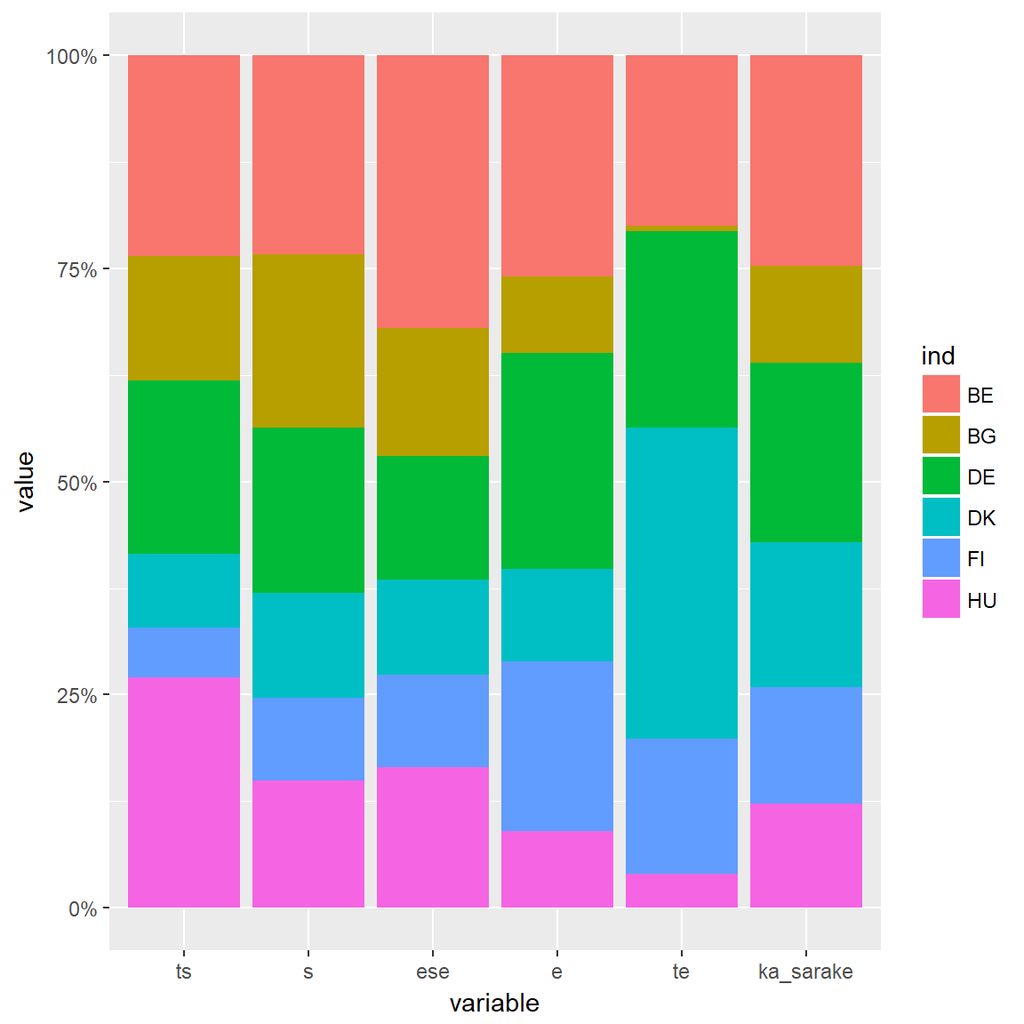

```r
#tauluG121 <- ISSP2012esim1.dat %>% tableX(maa, V6, type = "count")
#str(tauluG121)
#apu1 <- (tauluG121[-7, -6])
#str(apu1)
#apu1
#(rowSums(apu1))
#mutkikas kuvan piirto - sarakeprofiilit vertailussa
#ggplot vaatii df-rakenteen ja 'long data' - muotoon
#
# käytetään ca - tuloksia
apu1 <- (simpleCA1$N)
colnames(apu1) <- c("ts", "s", "ese", "e", "te")
rownames(apu1) <- c("BE", "BG", "DE", "DK", "FI", "HU")
apu1_df <- as.data.frame(apu1)
#lasketan rivien reunajakauma
apu1_df$ka_sarake <- rowSums(apu1_df)
#muokataan 'long data' - muotoon
apu1b_df <- melt(cbind(apu1_df, ind = rownames(apu1_df)), id.vars = c('ind'))

ggplot(apu1b_df, aes(x = variable, y = value, fill = ind)) +
         geom_bar(position = "fill", stat ="identity") +
         scale_y_continuous(labels = percent_format())
```

```r
#str(apu2_df)
#apu2_df
#apu1_df
#apu1b_df
```

Ensimmäinen korrespondenssianalyysi

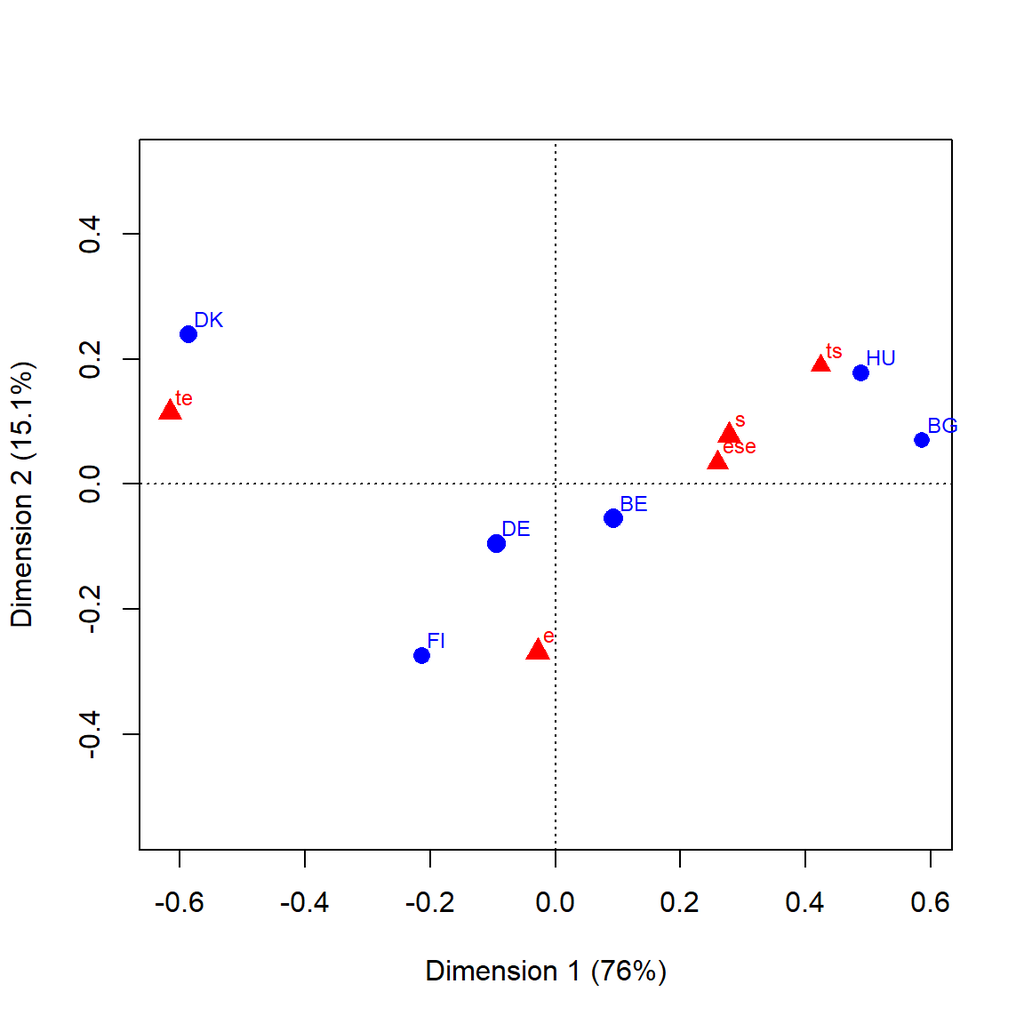

```r
#simpleCA1 <- ca(~maa + V6,ISSP2012esim1.dat) suoritetaan ennen värikuvaa, tuloksia tarvitaan siinä!
#symmetrinen kartta - asp=1 - optio ei toimi?
plot(simpleCA1, map = "symmetric", mass = c(TRUE,TRUE))
```

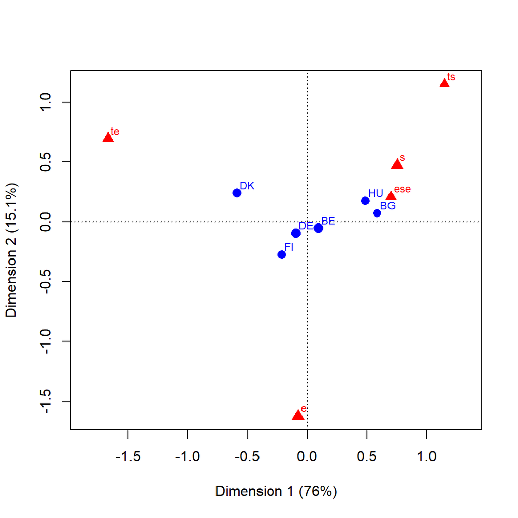

```r
#asymmetrinen kartta - rivit pc ja sarakkeet sc
plot(simpleCA1, map = "rowprincipal", mass = c(TRUE,TRUE))
```

```r
#str(simpleCA1)
```

## 2.2 Korrespondenssianalyysin käsitteet

1. Profiilit
2. Massat
3. Profiilien etäisyydet

**EDIT:** kaavaliitteessä (LaTeX) on kirjoiteltu valmiiksi - en vielä lisää (25.8.18)

# 3 Tulkinnan perusteita

```r
library(rgl)
library(ca)
library(haven)
library(dplyr)
library(knitr)
library(tidyverse)
library(lubridate)
library(rmarkdown)
library(ggplot2)
library(furniture)
library(likert)
library(scales) # G_1_2 - kuva
library(reshape2)  # G_1_2 - kuva
```

Luvussa syvennetään esimerkin tulkinnan perusteita. Miksi symmetrinen kartta on yleensä paras vaihtoehto, siksi se oletusarvoisesti esitetäänkin. Milloin voi käyttää vaihtoehtoisia esitystapoja? *Ydinluku*.

Esimerkkiaineistossa tulee jo pohdittavaa, Guttman (arc, horseshoe) - efekti, ratkaisun dimensiot jne.

# 4 Yksinkertaisen korrespondenssianalyysin laajennuksia

Korrespondenssianalyysi sallii rivien tai sarakkeiden yhdistelyn tai “jakamisen”. Tämä onnistuu esimerkkiaineistossa lisäämällä rivejä eli jakamalla eri maiden vastausksia useampaan ryhmään.

Sen avulla voi myös tarkastella ja vertailla erilaisia ryhmien välisiä tai ryhmien sisäisiä (within groups - between groups) eroja hieman. Teknisesti yksinkertaista korrespondenssianalyysiä sovelletaan muokattuun matriisiin. Datamatriisi rakennetaan useammasta alimatriisista, joko “pinoamalla” osamatriiseja (stacked matrices) tai muodostamalla symmetrinen lohkomatriisi (ABBA).

Lisätään esimerkkidataan uusia muuttujia, vastaajan luokitelut ikä ja sukupuoli.

## 4.1 Lisämuuttujat: ikäluokka ja sukupuoli

Luodaan aineistoon ikä- ja sukupuolimuuttujat

## 4.2 ABBA

## 4.3 Päällekkäiset matriisit (stacked matices)